# NCMA Final Client Package

Author

Kayla Cortez, Matthew Melgar, Jamie Min, Mehrnoosh Solgi, Roxana Rodriguez

Published

May 6, 2026

## Deliverable 1 — Final Dashboard (Looker Studio)

- Looker Studio Dashboard Link: https://datastudio.google.com/reporting/4666a95f-b65f-4ebd-bba3-ebf05ed9b699

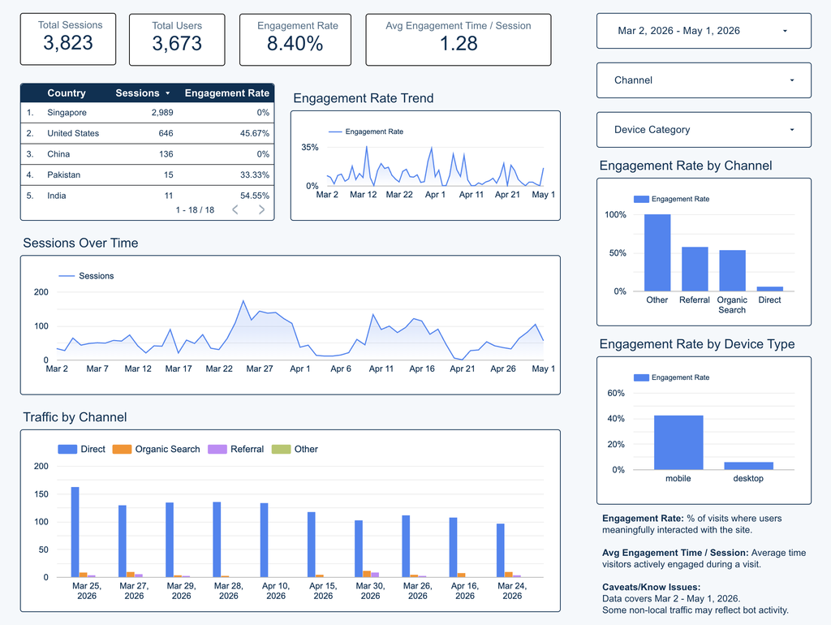

## Deliverable 2 — Final Quarto Report (reproducible)

### Narrative Summary of the Business Problem

NCMA SGV is a nonprofit, membership-based professional association chapter that serves contract management professionals, students, and early-career talent across the San Gabriel Valley region. The chapter creates value through professional development events, educational programming, networking opportunities, certification support, and leadership engagement. However, as the organization seeks to grow its local community and strengthen member participation, it needs a clearer understanding of how effectively its digital presence and event strategy are attracting, engaging, and converting its target audiences.

The primary business problem is that NCMA SGV must determine whether its website, social events, and digital marketing channels are successfully reaching the right audiences, especially Gen Z and early-career professionals, while also maintaining interest among established professionals in the San Gabriel Valley area. Although the organization provides valuable professional development and networking opportunities, it needs data-driven insight into whether users are discovering the website, engaging with relevant content, registering for events, subscribing to communications, and returning over time.

To address this challenge, NCMA SGV needs to track the full user journey from acquisition to engagement, conversion, and retention. Key metrics such as traffic source, user demographics, landing page engagement, event registration rate, subscription conversion rate, returning users, and retention rate can help the organization evaluate which channels and experiences are driving meaningful participation. By analyzing these behaviors, NCMA SGV can identify opportunities to improve website performance, optimize event promotion, strengthen audience targeting, and increase membership subscriptions.

Ultimately, the business problem centers on improving NCMA SGV’s ability to convert digital interest into measurable organizational growth. A stronger analytics framework will help the chapter understand who its audience is, how users interact with its website and events, and which strategies are most effective in building a sustainable and engaged contract management community.

### Descriptive Insights (From BigQuery/Mart)

```r
summary_time <- mart_df %>%
  group_by(date) %>%
  summarise(
    total_users = sum(users, na.rm = TRUE),
    total_sessions = sum(sessions, na.rm = TRUE),
    total_engaged_sessions = sum(engaged_sessions, na.rm = TRUE),
    total_engagement_time = sum(engagement_time_msec, na.rm = TRUE)
  ) %>%
  arrange(date)

summary_time
```

```
# A tibble: 60 × 5
   date       total_users total_sessions total_engaged_sessions
   <date>           <dbl>          <dbl>                  <dbl>
 1 2026-03-07          48             50                      2
 2 2026-03-08          49             49                      3
 3 2026-03-09          51             57                     10
 4 2026-03-10          53             55                      3
 5 2026-03-11          71             73                      8
 6 2026-03-12          40             41                      3
 7 2026-03-13          17             20                      7
 8 2026-03-14          40             41                      3
 9 2026-03-15          40             40                      0
10 2026-03-16          86             89                     12
# ℹ 50 more rows
# ℹ 1 more variable: total_engagement_time <dbl>
```

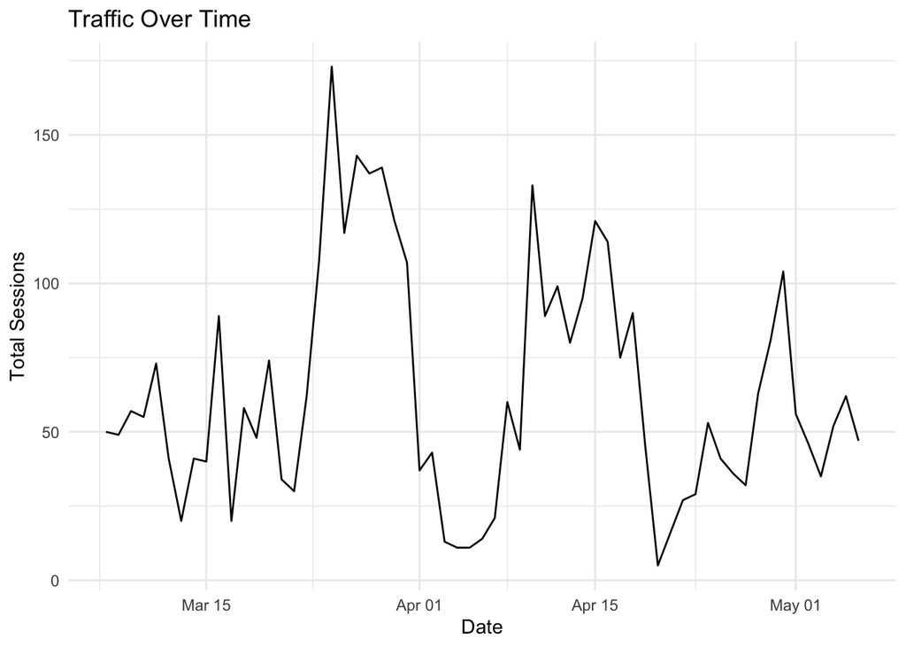

```r
ggplot(summary_time, aes(x = date, y = total_sessions)) +
  geom_line() +
  labs(
    title = "Traffic Over Time",
    x = "Date",
    y = "Total Sessions"
  ) +
  theme_minimal()
```

**Descriptive Insight:**

- Traffic fluctuates significantly over time with several spikes and drops. This indicates that traffic is very inconsistent, as it doesn’t have steady growth over time but is rather volatile due to irregular user activity.
- A major peak occurred in late March, where total sessions surpassed 150 compared to prior months.
- Traffic declined sharply in early April to below 50 sessions and spiked again mid-April.

```r
summary_channel <- mart_df %>%
  group_by(channel) %>%
  summarise(
    total_users = sum(users, na.rm = TRUE),
    total_sessions = sum(sessions, na.rm = TRUE),
    total_engaged_sessions = sum(engaged_sessions, na.rm = TRUE),
    total_engagement_time = sum(engagement_time_msec, na.rm = TRUE)
  ) %>%
  arrange(desc(total_sessions))

summary_channel
```

```
# A tibble: 4 × 5
  channel        total_users total_sessions total_engaged_sessions
  <chr>                <dbl>          <dbl>                  <dbl>
1 Direct                3542           3630                    203
2 Organic Search         101            156                     83
3 Referral                55             63                     36
4 Other                    1              1                      1
# ℹ 1 more variable: total_engagement_time <dbl>
```

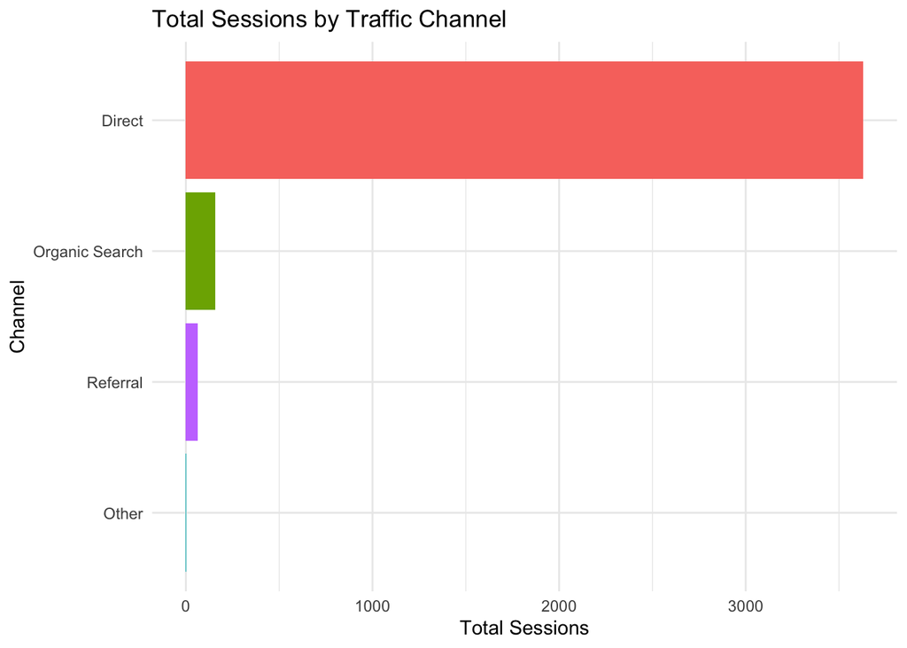

```r
ggplot(summary_channel, aes(x = reorder(channel, total_sessions),
                            y = total_sessions,
                            fill = channel)) +
  geom_col() +
  coord_flip() +
  labs(
    title = "Total Sessions by Traffic Channel",
    x = "Channel",
    y = "Total Sessions"
  ) +
  theme_minimal() +
  theme(legend.position = "none")
```

**Descriptive Insight:**

- Most website traffic is coming from direct traffic sources, and it accounts for approximately 90% of all user traffic.
- Organic Search contributes to a very small portion of traffic with fewer than 500 sessions.
- Referrals and other sources have minimal numbers.

```r
summary_country <- mart_df %>%
  group_by(country) %>%
  summarise(
    total_users = sum(users, na.rm = TRUE),
    total_sessions = sum(sessions, na.rm = TRUE),
    total_engaged_sessions = sum(engaged_sessions, na.rm = TRUE),
    total_engagement_time = sum(engagement_time_msec, na.rm = TRUE)
  ) %>%
  arrange(desc(total_sessions)) %>%
  slice_head(n = 5)

summary_country
```

```
# A tibble: 5 × 5
  country       total_users total_sessions total_engaged_sessions
  <chr>               <dbl>          <dbl>                  <dbl>
1 Singapore            3067           3067                      0
2 United States         505            651                    294
3 China                  76             76                      0
4 Pakistan               15             19                      9
5 India                  11             12                      6
# ℹ 1 more variable: total_engagement_time <dbl>
```

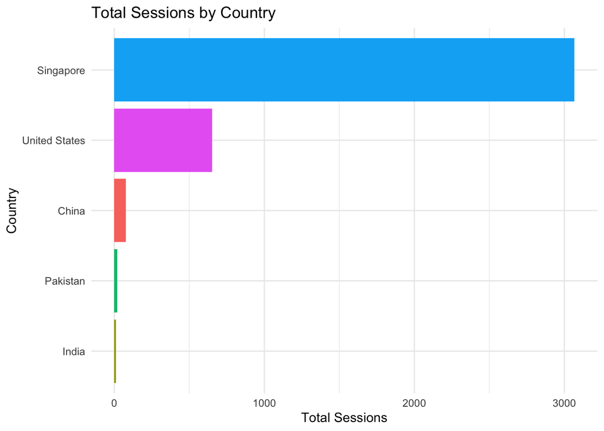

```r
ggplot(summary_country, aes(x = reorder(country, total_sessions),
                            y = total_sessions,
                            fill = country)) +
  geom_col() +
  coord_flip() +
  labs(
    title = "Total Sessions by Country",
    x = "Country",
    y = "Total Sessions"
  ) +
  theme_minimal() +
  theme(legend.position = "none")
```

```r
summary_device <- mart_df %>%
  group_by(device_category) %>%
  summarise(
    total_users = sum(users, na.rm = TRUE),
    total_sessions = sum(sessions, na.rm = TRUE),
    total_engaged_sessions = sum(engaged_sessions, na.rm = TRUE),
    total_engagement_time = sum(engagement_time_msec, na.rm = TRUE)
  ) %>%
  arrange(desc(total_sessions))

summary_device
```

```
# A tibble: 2 × 5
  device_category total_users total_sessions total_engaged_sessions
  <chr>                 <dbl>          <dbl>                  <dbl>
1 desktop                3502           3567                    205
2 mobile                  197            283                    118
# ℹ 1 more variable: total_engagement_time <dbl>
```

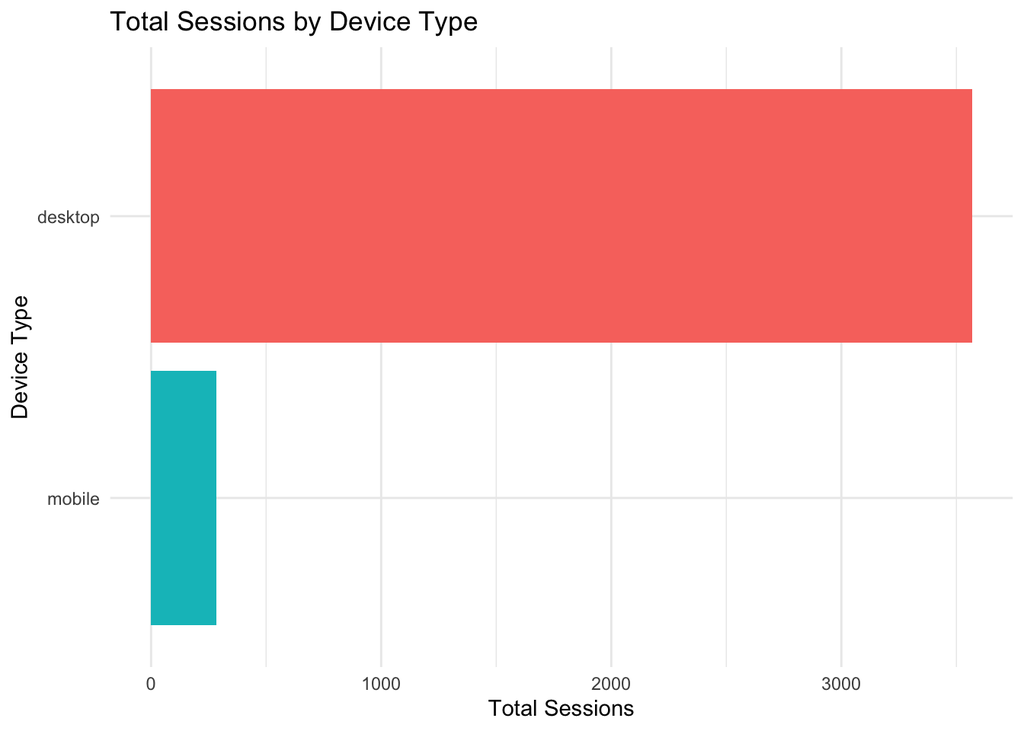

```r
ggplot(summary_device, aes(x = reorder(device_category, total_sessions),
                           y = total_sessions,
                           fill = device_category)) +
  geom_col() +
  coord_flip() +
  labs(
    title = "Total Sessions by Device Type",
    x = "Device Type",
    y = "Total Sessions"
  ) +
  theme_minimal() +
  theme(legend.position = "none")
```

**Descriptive Insight:**

- Desktop seems to outweigh mobile users, as desktop traffic accounts for the majority of traffic sessions to the website compared to mobile users, who represent a smaller portion of the traffic.
- Since the majority of traffic comes from desktop devices, this suggests that most users access the site in more professional contexts, which aligns with NCMA’s purpose, as it primarily serves a professional audience interested in networking.

```r
summary_engagement <- mart_df %>%
  group_by(channel) %>%
  summarise(
    total_sessions = sum(sessions, na.rm = TRUE),
    total_engaged_sessions = sum(engaged_sessions, na.rm = TRUE),
    engagement_rate = total_engaged_sessions / total_sessions,
    total_engagement_time = sum(engagement_time_msec, na.rm = TRUE)
  ) %>%
  arrange(desc(engagement_rate))

summary_engagement
```

```
# A tibble: 4 × 5
  channel        total_sessions total_engaged_sessions engagement_rate
  <chr>                   <dbl>                  <dbl>           <dbl>
1 Other                       1                      1          1
2 Referral                   63                     36          0.571
3 Organic Search            156                     83          0.532
4 Direct                   3630                    203          0.0559
# ℹ 1 more variable: total_engagement_time <dbl>
```

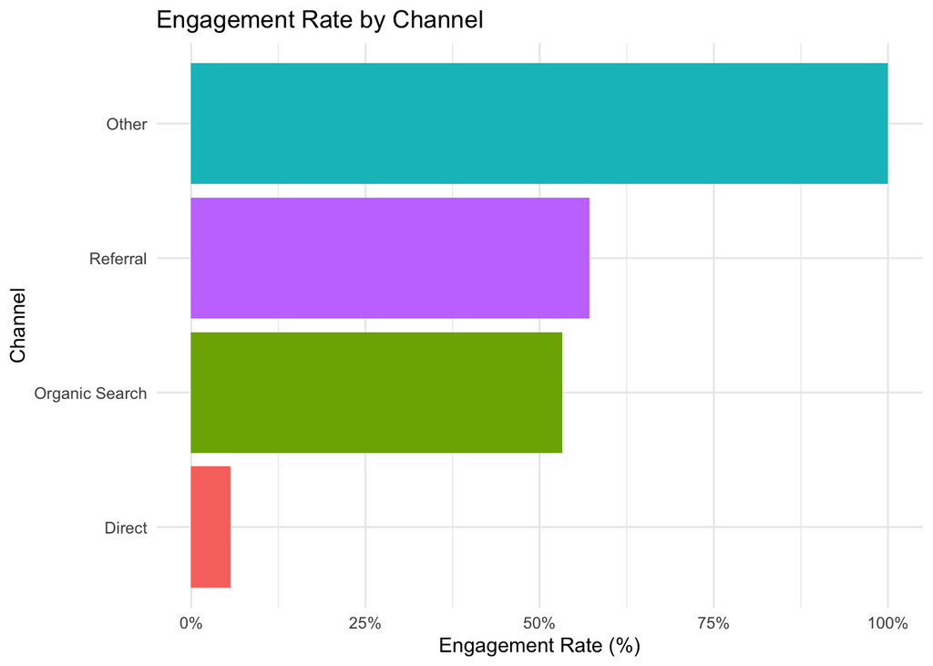

```r
ggplot(summary_engagement, aes(x = reorder(channel, engagement_rate),
                               y = engagement_rate,
                               fill = channel)) +
  geom_col() +
  coord_flip() +
  scale_y_continuous(labels = percent_format()) +
  labs(
    title = "Engagement Rate by Channel",
    x = "Channel",
    y = "Engagement Rate (%)"
  ) +
  theme_minimal() +
  theme(legend.position = "none")
```

**Descriptive Insight:**

- “Other” traffic sources shows the highest engagement, while referral and organic search have a moderate amount of engagement with 50%-60%
- Direct traffic has the lowest engagement rate, around 5–10%, suggesting that these users are not interacting meaningfully with the website despite generating the highest volume of traffic. This audience segment may also consist largely of low-intent users.

**Key Takeaway:**

The website is relying heavily on direct traffic. However, this dominant source appears to be low quality in terms of engagement, while smaller channels such as organic search and referral drive more meaningful user interactions. Traffic patterns over time are also significantly inconsistent, with noticeable spikes that suggest specific event activity rather than steady growth. Additionally, the audience is primarily in Singapore, and NCMA SGV aims to attract a professionally oriented user base from the U.S

### Advanced Analysis (attribution required)

```r
#| label: attribution-analysis

attribution_summary <- mart_df |>
  group_by(channel) |>
  summarise(
    total_sessions = sum(sessions, na.rm = TRUE),
    total_engaged_sessions = sum(engaged_sessions, na.rm = TRUE),
    engagement_rate = total_engaged_sessions / total_sessions,
    total_engagement_time = sum(engagement_time_msec, na.rm = TRUE) / 100
  ) |>
  arrange(desc(total_sessions))

attribution_summary
```

```
# A tibble: 4 × 5
  channel        total_sessions total_engaged_sessions engagement_rate
  <chr>                   <dbl>                  <dbl>           <dbl>
1 Direct                   3630                    203          0.0559
2 Organic Search            156                     83          0.532
3 Referral                   63                     36          0.571
4 Other                       1                      1          1
# ℹ 1 more variable: total_engagement_time <dbl>
```

### Recommendations and Limitations

#### **Recommendations**

Implementing a multi-touch attribution as a standard reporting framework would allow for observing differences between attribution outputs and last-click assumptions to highlight the risk of undervaluing upper-funnel interactions. Adopting a data driven or position based attribution model will provide a more accurate representation of the customer journey and support more well-informed media allocation decisions.

The next step would be to optimize underperforming channels through targeted experimentation rather than elimination. Channels with lower attributed value may still play a supporting role in awareness or assisted conversions. Structured A/B testing on messaging, targeting, and landing page alignment can help determine whether performance gaps are due to execution rather than channel viability.

It is also necessary to strengthen tracking consistency across all digital touchpoints. Ensuring standardized event naming conventions, complete parameter capture, and reliable cross-platform integration within GA4, BigQuery, and reporting layers will improve data quality and enable more precise downstream analysis.

To fully implement a method towards remaining on top of KPIs, there must be an objective to develop a recurring dashboard review cadence tied to business objectives. Rather than treating reporting as static, stakeholders should evaluate channel performance on a scheduled basis, aligning insights with campaign cycles and broader marketing goals to drive continuous optimization.

#### **Limitations**

The analysis relies on aggregated data from the mart table, which limits visibility into user-level behavior. Without granular session or user journey data, certain attribution patterns may be simplified, potentially masking nuanced interactions across touchpoints.

Attribution modeling assumptions introduce inherent uncertainty. Even with advanced attribution approaches, no model can fully capture the complexity of real-world decision-making. As a result, attributed values should be interpreted as estimates rather than exact representations of causal impact.

Discrepancies between data sources may affect consistency. Differences between GA4 interface reporting and BigQuery exports driven by factors such as data processing latency, sampling thresholds, and filtering rules can lead to minor variations in reported metrics. Tracking implementation constraints may impact data completeness. Issues such as missing UTM parameters, inconsistent tagging, consent mode restrictions, or cross-domain tracking gaps can result in underreported or misattributed interactions.

Another limitation is the relatively short or static analysis window. Channel performance can vary significantly over time due to seasonality, campaign changes, or external market conditions. As such, findings should be validated against longer-term trends before making major strategic shifts.

This analysis does not fully incorporate offline or external influences. Factors such as brand awareness, word-of-mouth, or offline marketing efforts may contribute to observed outcomes but are not captured within the current digital measurement framework.

Taken together, these limitations suggest that the findings should be used as a strategic guide rather than a definitive prescription, and should be continuously refined as additional data becomes available.

### Reproducible Code and Instructions

This report can be reproduced because it uses the same cleaned data source for all of the charts and analysis. The main data source is the BigQuery table called `mart_daily_acquisition_v1`. This table is in the dataset `analytics_385372747` and the Google Cloud project `ncma-cpp-spring`.

To reproduce this report, the user needs access to the GitHub repository and the BigQuery table.

Required tools:

- R
- Quarto
- Git
- RStudio, Positron, or another Quarto editor
- Google BigQuery access

Required R packages:

- `bigrquery`
- `DBI`
- `dbplyr`
- `dplyr`
- `tidyverse`
- `purrr`
- `slider`
- `ggplot2`
- `readr`
- `scales`

Steps to reproduce the report:

1. Download or clone the group GitHub repo.
2. Open the project folder in RStudio, Positron, or another Quarto editor.
3. Open the final `.qmd` file.
4. Sign in to the Google account that has access to the BigQuery project.
5. Click **Render**.
6. Check that the HTML report is created.
7. Open the dashboard link and make sure it still works.

The report uses this BigQuery code to load the cleaned mart:

```r
library(bigrquery)
library(DBI)
library(dbplyr)
library(dplyr)

bq_auth()

project_id <- "ncma-cpp-spring"
dataset_id <- "analytics_385372747"

con <- dbConnect(
  bigrquery::bigquery(),
  project = project_id,
  dataset = dataset_id,
  billing = project_id
)

mart_df <- tbl(con, "mart_daily_acquisition_v1") %>%
  collect() %>%
  arrange(desc(date))
```

The report uses the BigQuery mart to make the summary tables, charts, insights, and recommendations. The report should keep working as long as the BigQuery project, dataset, table name, and columns stay the same.

## Deliverable 3 — Team Presentation (instructor-specified format)

**Revealjs Presentation Link: https://roxanar1.github.io/NCMA-Final-Client-Package/**

**Repo Link: https://github.com/roxanar1/NCMA-Final-Client-Package.git**